# ch05_03_02_validation(2)_threshold_v11_2610

📚 참고: 이 실습은 『파이썬 라이브러리를 활용한 머신러닝』(안드레아스 뮐러·세라 가이도 지음, 박해선 옮김, 한빛미디어) 예제와 저자의 `mglearn` 패키지(BSD 라이선스)를 바탕으로 합니다.

> 🛠️ **2026.10 수정본 (v11)** — 원본: `ch05_03_02_validation(2)_threshold.ipynb`
> - mglearn 0.2.0의 `make_blobs`가 `n_samples=(400, 50), centers=2` 조합을 못 받아서, 예전 mglearn과 **똑같은 데이터**를 만드는 함수를 노트북 안에 넣었어요.

### 모델 검증

- 임계값에 따른 평가지표 확인

#### 1.1.1 이진 분류의 평가지표

## 1.1.2 임계값과 평가지표

#### 1.1.3 평가지표 - ROC 커브, AUC

#### 1.1.4 다중 분류의 평가지표

### 학습 내용

- 예측을 0,1로 하는 것이 아니라 0이 될 확률, 1이 될 확률로 예측 하기.
- 임계값을 조정하는 것에 따라 정밀도와 민감도가 변하는 것을 확인해 본다.

### 목차

01. 데이터 준비 및 라이브러리 임포트  
02. 모델(SVC) 예측 후, 평가 지표 확인

### 이진 분류 예측 - 예측을 0,1로 하는 것이 아니라 확률로 해보기

- 400개(음성), 50개(양성) 으로 이루어진 불균형 데이터
- 사용 함수 : decision_function(), predict_proba()
  - decision_function을 0으로, predict_proba를 0.5의 임계값으로 사용

### 01. 데이터 준비 및 라이브러리 임포트

목차로 이동하기

```python
import warnings
warnings.filterwarnings(action='ignore')
```

```python
from sklearn.model_selection import train_test_split
from sklearn.svm import SVC
import mglearn
from sklearn.metrics import classification_report
import matplotlib.pyplot as plt
import numpy as np
```

```python
# 2026.10 수정: 예전 mglearn의 make_blobs는 n_samples=(400, 50)처럼 클래스별 개수와 centers=2를 같이 받았는데,
# mglearn 0.2.0부터는 sklearn의 make_blobs를 그대로 써서 이 조합이 ValueError가 납니다.
# 예전과 똑같은 데이터가 나오도록 예전 mglearn 방식을 그대로 옮긴 함수입니다.
import numpy as np

def make_blobs(n_samples, centers=2, cluster_std=1.0, random_state=None,
               n_features=2, center_box=(-10.0, 10.0)):
    rng = np.random.RandomState(random_state)
    centers = rng.uniform(center_box[0], center_box[1], size=(centers, n_features))  # 중심점을 무작위로
    X, y = [], []
    for i, (n, std) in enumerate(zip(n_samples, cluster_std)):
        X.append(centers[i] + rng.normal(scale=std, size=(n, n_features)))  # 중심점 주변에 n개
        y += [i] * n
    X, y = np.concatenate(X), np.array(y)
    idx = np.arange(len(y))
    rng.shuffle(idx)  # 클래스 순서를 섞기
    return X[idx], y[idx]
```

```python
# from mglearn.datasets import make_blobs  # 2026.10 수정: 바로 위 셀의 make_blobs 함수를 씁니다

### 데이터 만들기 400개, 50개
X, y = make_blobs(n_samples=(400, 50),
                  centers=2,
                  cluster_std=[7.0, 2],         # 클러스터의 표준 편차
                  random_state=42)

print(X.shape, y.shape)

X_train, X_test, y_train, y_test = train_test_split(X, y, random_state=0)
```

```
(450, 2) (450,)
```

```python
X_train[0:10], y_train[0:10]
```

```
(array([[-0.18299954,  3.77488037],
        [-2.73847051,  5.21031273],
        [ 4.14376924,  4.97596054],
        [ 5.21160962,  2.64208326],
        [ 1.78996928, 14.3168401 ],
        [ 1.09604925, 12.61078778],
        [-2.16954623,  3.19763531],
        [-8.04251881, 12.31456463],
        [-0.48077362, 23.54209172],
        [-8.287678  ,  6.76458524]]),
 array([0, 0, 0, 1, 0, 0, 0, 0, 0, 0]))
```

### 데이터 시각화

- 400개의 음성 클래스
- 50개의 양성 클래스

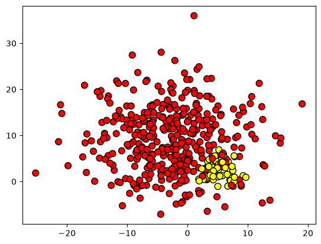

```python
plt.scatter(X[:,0], X[:,1],
            c=y,
            cmap=plt.cm.autumn, s=60, edgecolors='k')
```

### 임계값에 따른 값을 확인

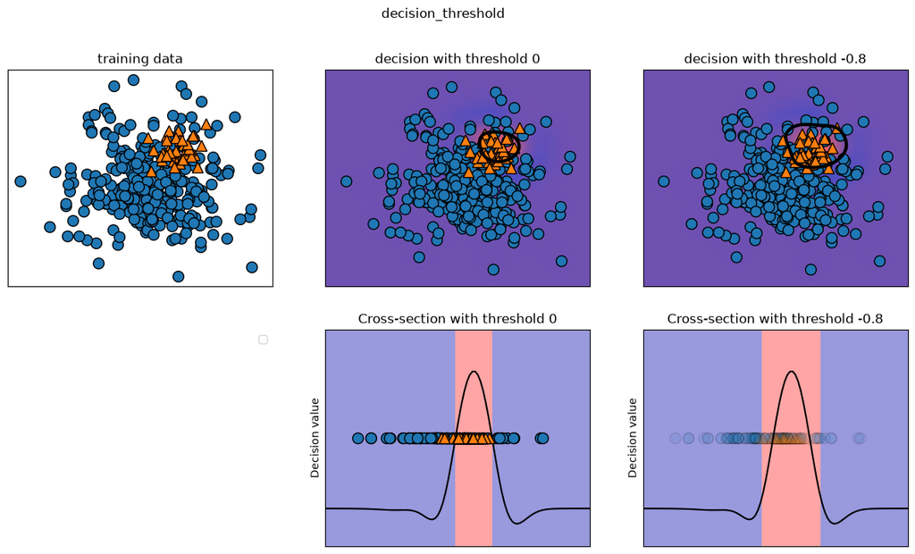

```python
mglearn.plots.plot_decision_threshold()
```

- 중앙 웟부분에 있는 검은 원은 decision_function이 정확히 0일 때의 임계점을 나타낸다.
- 원안의 포인트는 **양성 클래스**로 분류, 바깥쪽 포인트는 **음성 클래스**로 분류

### 재현율(recall) 조정해보기

- svc.predict()함수로 예측 시. 재현율을 조정하기 어려운 조건.
- decision_function()함수로 예측하여 임계값이 조정이 가능.

### 02. 모델(SVC) 예측 후, 평가 지표 확인

목차로 이동하기

- 모델 : SVC(support vector machine)
- 정밀도, 민감도, f1-score 확인

```python
svc = SVC(gamma=.05).fit(X_train, y_train)
pred = svc.predict(X_test)
print(classification_report(y_test, pred))
```

```
              precision    recall  f1-score   support

           0       0.99      0.93      0.96       107
           1       0.42      0.83      0.56         6

    accuracy                           0.93       113
   macro avg       0.70      0.88      0.76       113
weighted avg       0.96      0.93      0.94       113
```

### 모델의 임계값을 활용하여 0,1 개수 조정

- 임계값을 0에서 -0.8로 낮추기
- 임계값을 0에서 -0.8로 조정시 양성 클래스(1)의 개수가 늘어난다.

```python
pred = svc.decision_function(X_test)

print(pred[0:10])
np.min(pred), np.max(pred)
```

```
[-1.0167542   0.72583536 -1.17766946 -1.00425497 -1.0002495  -0.99977182
 -1.07285711 -1.2206812  -1.24018502 -1.30361098]
```

```
(np.float64(-1.5097072536209504), np.float64(1.6245457437087514))
```

```python
decision_0 = svc.decision_function(X_test)   > 0     # 임계값을 0으로

print("임계값 0 일때    : 1(양성) 개수 :", decision_0.sum() )
print("임계값 0 일때    : 0(음성) 개수 :", len(decision_0) - decision_0.sum() )
```

```
임계값 0 일때    : 1(양성) 개수 : 12
임계값 0 일때    : 0(음성) 개수 : 101
```

```python
decision_m08 = svc.decision_function(X_test) > -.8   # 임계값을 -0.8로

# 임계값을 낮추므로 예측의 Positive를 늘린다. TP, FP가 늘어난다.
print("임계값 -0.8 일때 : 1(양성) 개수 :", decision_m08.sum() )
print("임계값 -0.8 일때 : 0(음성) 개수 :", len(decision_m08) - decision_m08.sum() )
```

```
임계값 -0.8 일때 : 1(양성) 개수 : 18
임계값 -0.8 일때 : 0(음성) 개수 : 95
```

- 임계값을 낮추는 것은 예측 Positive를 늘리고,
- 임계값을 높이는 것은 예측 Positive의 개수를 줄인다.

```python
y_pred_0 = svc.decision_function(X_test)   > 0
y_pred_08 = svc.decision_function(X_test) > -.8
```

```python
# 임계값 0
print(classification_report(y_test, y_pred_0))
```

```
              precision    recall  f1-score   support

           0       0.99      0.93      0.96       107
           1       0.42      0.83      0.56         6

    accuracy                           0.93       113
   macro avg       0.70      0.88      0.76       113
weighted avg       0.96      0.93      0.94       113
```

```python
print(classification_report(y_test, y_pred_08))
```

```
              precision    recall  f1-score   support

           0       1.00      0.89      0.94       107
           1       0.33      1.00      0.50         6

    accuracy                           0.89       113
   macro avg       0.67      0.94      0.72       113
weighted avg       0.96      0.89      0.92       113
```

### 임계값을 낮추는 것은

- 정밀도(precision) **0.42에서 0.33로 낮아지고**
- 재현율(recall)-sensitivity(민감도)는 **0.83에서 1로 올라감.**
- 결론적으로 **1(양성)의 수가 늘어나기 때문에 TP(진짜 양성)의 개수가 늘어난다.**
- TP, FP를 함께 늘려주기 때문에 정밀도는 낮아진다.
- TP, FP가 늘어나지만, 상대적으로 FN이 줄어들기에, 이에 관련된 민감도의 값을 높아지게 된다.

### Review

- 정밀도(precision)
  - TP/(TP + FP) : **예측 양성 전체 중**에 정확하게 잘 맞추었을까?
- 민감도 or 재현율(recall) :
  - TP/(TP + FN) : 실제 양성 데이터의 얼마나 잘 맞추었을까?
  - 다른 말로 **민감도(sensitivity), 적중률(hit rate), 진짜 양성 비율(TPR)**이라고 합니다.
- F1-score \begin{equation} \text{F} = 2 * \frac{\text{정밀도*재현율}}{ \text{정밀도 + 재현율 } } \end{equation}

### 실습

- 임계값을 0보다 큰 값으로 조정해 보고 재현율(recall)를 확인해 보기
- 임계값을 0으로 하고 재현율(recall)과 기타 평가지표를 확인해 보기

### 기타 방법

- predict_proba()메서드는 출력이 0에서 1 사이로 고정
  - 보통은 0.5를 임계값-이는 양성과 음성이 50%분류이다.
  - 임계값을 높이는 것은 양성이 분류될 확률이 많이 나올 때, 수행

교육용으로 작성된 것으로 배포 및 복제시에 사전 허가가 필요합니다.  
Copyright 2022 LIM Co. all rights reserved.